# [EN] Collaborative Governance in La Convención during the COVID-19 Pandemic

Executive summary of my findings in my Subnational Variation in Collaborative Governance: Peru’s Indigenous COVID Commands and La Convención’s Participative Legacy project

Published

March 27, 2026

*How can we explain the variation between Indigenous COVID Commands’ (ICCs) performances? More specifically, how did La Convención’s ICC achieve better results than other ICCs, measured in terms of vaccination rates? I argue La Convención’s ICC has fared better than others for two reasons: (1) the province’s health-related collaborative legacy, and (2) the involvement of trusted non-governmental organizations (NGOs) in the ICC.*

*The following is a summary of my project* Subnational Variation in Collaborative Governance: Peru’s Indigenous COVID Commands and La Convención’s Participative Legacy*, which mainly draws on interview and archival data collected in 2022. The article (under review) I wrote on this topic contains much more detail on the functioning and outcomes of the ICC. I’ll be happy to share a copy if you reach out.*

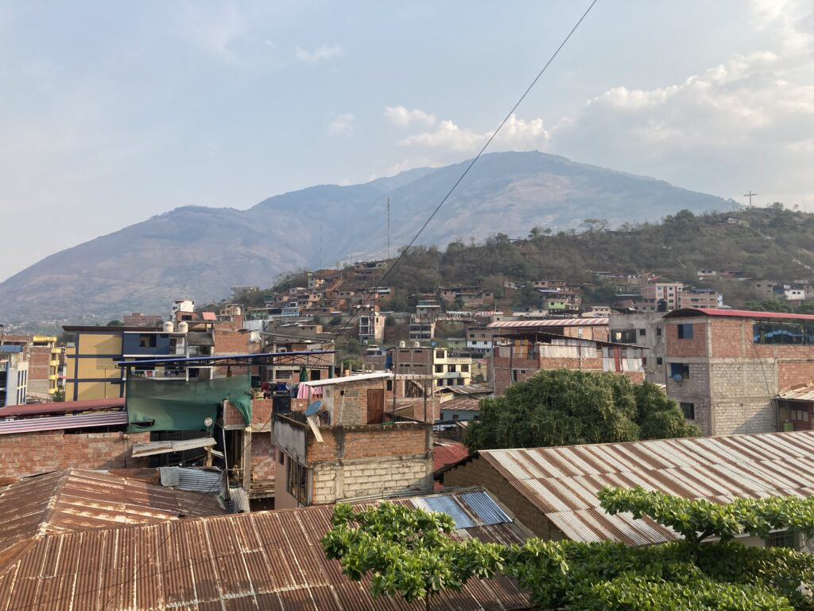

## COVID-19 in Peru’s Amazon

At the onset of the COVID-19 pandemic, the Peruvian government put into place a slew of health-related measures to mitigate the virus’s impacts. These measures included school and workplace closures, mobility and gathering restrictions, obligation to wear masks, and more. Designed for the general population, these measures did not always consider indigenous populations’ particular needs and practices. Therefore, Indigenous COVID Commands (ICCs) were created in ten of the country’s departments to mitigate the virus’s impact on Amazonian indigenous communities, by distributing informative material, protective equipment, and vaccines.

On paper, the ICCs were designed as collaborative governance spaces—in other words, organizations that brought together state officials and indigenous representatives, to encourage dialogue and participative decision-making. In reality, however, many ICCs did not foster a truly collaborative approach. Indeed, state officials were reportedly minimally involved in the collaborative process, instead making decisions unilaterally.

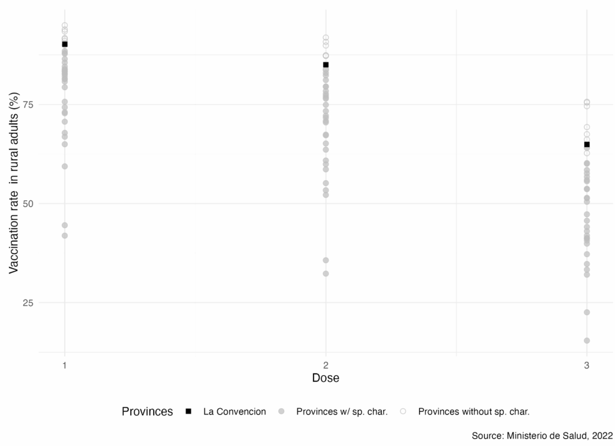

Below, I answer this question by considering La Convención’s history, marked by collaboration between social actors, and then examining how the ICC functioned.

## An Exceptional Collaborative Legacy

The first part of our answer rests in La Convención’s legacy of collaboration. The province has long had a spirit of reunion: La Convención was the scene of popular revolts against large landowners, mobilizing 300 000 workers of the coffee industry between 1959 and 1963. These protests paved the way for major land reforms in the region, then the country.

More recently, La Convención was home to the *La Convención Health Coordination Table* (LCHCT). Created around the turn of the century by civil society actors and state officials, the Table functioned informally until its official recognition by the Cusco regional government in 2007. Initially solely focused on health-related measures, the Table gradually expanded its horizons and became the major cross-sectorial collaboration space in the province, and the only one in Cusco which gathered Amazonian indigenous communities, organizations from the wider civil society and state representatives. One of the ICC’s key actors, NGO A, entered the LCHCT in 2001, where it used its previous experience in intermediation and health to strengthen the Table’s collaborative process.

Thus, La Convención benefits from a particular heritage, as its past is characterized by the existence of active health-related collaborative spaces. I argue this experience allowed La Convención’s ICC to function better than other ICCs, as actors in the province already knew one another and had institutional experience in collaborating.

## NGOs as Key Stakeholders of La Convención’s ICC

The second part of our answer rests on the functioning of La Convención’s ICC. The ministerial resolutions creating ICCs did not plan for the participation of NGOs in these spaces. Likewise, scholarship on the ICCs does not understand NGOs to play an important role in their functioning. Yet, in La Convención, NGOs were integral to the ICC—in its creation, the collaboration dynamics, and its outcomes.

### Creation

At the beginning of the pandemic, the impulsion for the creation of a collaborative space in La Convención appears to have come from multiple actors. Indeed, both an indigenous representative and a state official from the Ministry of Culture told me they had proposed the creation of an informal group to manage the pandemic’s impact on indigenous communities. Both actors nevertheless affirmed that NGOs, among them NGO A, were there present from the beginning. As the pandemic continued, the informal space was transformed into a state-sanctioned ICC through a slew of ministerial resolutions.

### Collaboration

Collaboration within La Convención’s ICC was not always smooth sailing. Indeed, indigenous representatives voiced concerns that the Ministry of Health (MINSA) did hear their concerns and failed to adopt an intercultural approach to healthcare; NGO workers deplored that MINSA officials saw them purely as sources of funding, rather than actors to collaborate with; and MINSA officials were accused of not always following collaborative procedures, rather taking unilateral decisions. Nevertheless, as one of the participants stated, the ICC’s NGOs and Cusco agency for Culture formed a sort of “steering committee”, which kept the ICC active even when the Ministry of Health failed their responsibilities.

### Outcomes

La Convención’s ICC made three outcomes possible: (1) the distribution of informative material related to the coronavirus, (2) the distribution of protective equipment to medical staff and indigenous communities, and (3) the realization of a vaccination campaign. These actions were made possible by the collaboration of the ICC’s actors. Taking the vaccination campaign as an example, MINSA provided the vaccines and medical staff; NGO B provided logistical support; NGO A, NGO B and the Ministry of Culture provided help in intercultural communication and intermediation; and the indigenous representatives provided leadership and deep knowledge of their communities.

In conclusion, I argue La Convención’s high vaccination rates can be explained by two factors: (1) its legacy of health-related collaboration, which favoured the rapid establishment of collaborative spaces during the pandemic, and (2) the presence of NGOs in the ICC, which given their leadership and legitimacy, were able to help keep the ICC afloat even when MINSA was uncommitted to its collaborative ideals. In turn, I suggest this explains the variation in the performance of ICCs across the country, as it appears most of them did not benefit from NGOs’ committed participation and from a history of collaboration.

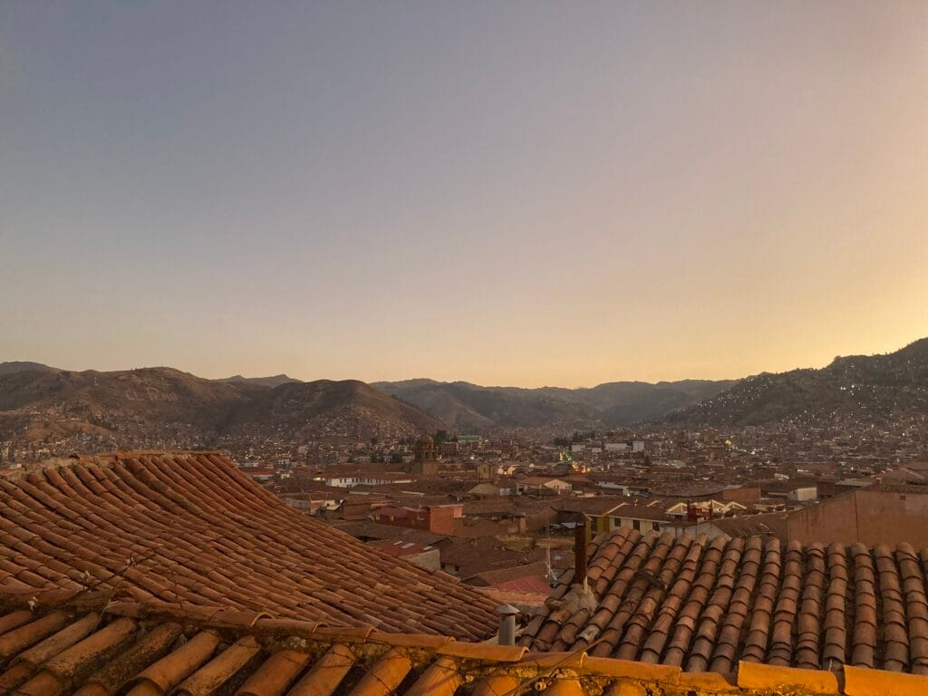